# Risk Factor Analysis

## Outcome Variable

**Outcome Variable:** ever_stunted

## Predictor Variables

**Intervention Variable:** predexfd6

**Adjustment Set:**

unadjusted

## Stratifying Variables

The analysis was stratified on these variable(s):

- agecat
- studyid
- country

## Data Summary

| agecat | studyid | country | predexfd6 | ever_stunted | n_cell | n |
| --- | --- | --- | --- | --- | --- | --- |
| 0-24 months (no birth st.) | CMC-V-BCS-2002 | INDIA | 1 | 0 | 1 | 14 |
| 0-24 months (no birth st.) | CMC-V-BCS-2002 | INDIA | 1 | 1 | 13 | 14 |
| 0-24 months (no birth st.) | CMC-V-BCS-2002 | INDIA | 0 | 0 | 0 | 14 |
| 0-24 months (no birth st.) | CMC-V-BCS-2002 | INDIA | 0 | 1 | 0 | 14 |
| 0-24 months (no birth st.) | EE | PAKISTAN | 1 | 0 | 4 | 27 |
| 0-24 months (no birth st.) | EE | PAKISTAN | 1 | 1 | 19 | 27 |
| 0-24 months (no birth st.) | EE | PAKISTAN | 0 | 0 | 2 | 27 |
| 0-24 months (no birth st.) | EE | PAKISTAN | 0 | 1 | 2 | 27 |
| 0-24 months (no birth st.) | GMS-Nepal | NEPAL | 1 | 0 | 130 | 471 |
| 0-24 months (no birth st.) | GMS-Nepal | NEPAL | 1 | 1 | 222 | 471 |
| 0-24 months (no birth st.) | GMS-Nepal | NEPAL | 0 | 0 | 34 | 471 |
| 0-24 months (no birth st.) | GMS-Nepal | NEPAL | 0 | 1 | 85 | 471 |
| 0-24 months (no birth st.) | IRC | INDIA | 1 | 0 | 0 | 13 |
| 0-24 months (no birth st.) | IRC | INDIA | 1 | 1 | 0 | 13 |
| 0-24 months (no birth st.) | IRC | INDIA | 0 | 0 | 4 | 13 |
| 0-24 months (no birth st.) | IRC | INDIA | 0 | 1 | 9 | 13 |
| 0-24 months (no birth st.) | JiVitA-3 | BANGLADESH | 1 | 0 | 6247 | 10809 |
| 0-24 months (no birth st.) | JiVitA-3 | BANGLADESH | 1 | 1 | 2191 | 10809 |
| 0-24 months (no birth st.) | JiVitA-3 | BANGLADESH | 0 | 0 | 1776 | 10809 |
| 0-24 months (no birth st.) | JiVitA-3 | BANGLADESH | 0 | 1 | 595 | 10809 |
| 0-24 months (no birth st.) | JiVitA-4 | BANGLADESH | 1 | 0 | 1565 | 3397 |
| 0-24 months (no birth st.) | JiVitA-4 | BANGLADESH | 1 | 1 | 1125 | 3397 |
| 0-24 months (no birth st.) | JiVitA-4 | BANGLADESH | 0 | 0 | 393 | 3397 |
| 0-24 months (no birth st.) | JiVitA-4 | BANGLADESH | 0 | 1 | 314 | 3397 |
| 0-24 months (no birth st.) | Keneba | GAMBIA | 1 | 0 | 401 | 2023 |
| 0-24 months (no birth st.) | Keneba | GAMBIA | 1 | 1 | 350 | 2023 |
| 0-24 months (no birth st.) | Keneba | GAMBIA | 0 | 0 | 566 | 2023 |
| 0-24 months (no birth st.) | Keneba | GAMBIA | 0 | 1 | 706 | 2023 |
| 0-24 months (no birth st.) | LCNI-5 | MALAWI | 1 | 0 | 18 | 175 |
| 0-24 months (no birth st.) | LCNI-5 | MALAWI | 1 | 1 | 12 | 175 |

[output cut: 186 more lines]

The following strata were considered:

- agecat: 0-24 months (no birth st.), studyid: CMC-V-BCS-2002, country: INDIA
- agecat: 0-24 months (no birth st.), studyid: EE, country: PAKISTAN
- agecat: 0-24 months (no birth st.), studyid: GMS-Nepal, country: NEPAL
- agecat: 0-24 months (no birth st.), studyid: IRC, country: INDIA
- agecat: 0-24 months (no birth st.), studyid: JiVitA-3, country: BANGLADESH
- agecat: 0-24 months (no birth st.), studyid: JiVitA-4, country: BANGLADESH
- agecat: 0-24 months (no birth st.), studyid: Keneba, country: GAMBIA
- agecat: 0-24 months (no birth st.), studyid: LCNI-5, country: MALAWI
- agecat: 0-24 months (no birth st.), studyid: MAL-ED, country: BANGLADESH
- agecat: 0-24 months (no birth st.), studyid: MAL-ED, country: BRAZIL
- agecat: 0-24 months (no birth st.), studyid: MAL-ED, country: INDIA
- agecat: 0-24 months (no birth st.), studyid: MAL-ED, country: NEPAL
- agecat: 0-24 months (no birth st.), studyid: MAL-ED, country: PERU
- agecat: 0-24 months (no birth st.), studyid: MAL-ED, country: SOUTH AFRICA
- agecat: 0-24 months (no birth st.), studyid: MAL-ED, country: TANZANIA, UNITED REPUBLIC OF
- agecat: 0-24 months (no birth st.), studyid: PROVIDE, country: BANGLADESH
- agecat: 0-24 months (no birth st.), studyid: SAS-CompFeed, country: INDIA
- agecat: 0-24 months (no birth st.), studyid: SAS-FoodSuppl, country: INDIA
- agecat: 0-6 months (no birth st.), studyid: CMC-V-BCS-2002, country: INDIA
- agecat: 0-6 months (no birth st.), studyid: EE, country: PAKISTAN
- agecat: 0-6 months (no birth st.), studyid: GMS-Nepal, country: NEPAL
- agecat: 0-6 months (no birth st.), studyid: IRC, country: INDIA
- agecat: 0-6 months (no birth st.), studyid: JiVitA-3, country: BANGLADESH
- agecat: 0-6 months (no birth st.), studyid: JiVitA-4, country: BANGLADESH
- agecat: 0-6 months (no birth st.), studyid: Keneba, country: GAMBIA
- agecat: 0-6 months (no birth st.), studyid: LCNI-5, country: MALAWI
- agecat: 0-6 months (no birth st.), studyid: MAL-ED, country: BANGLADESH
- agecat: 0-6 months (no birth st.), studyid: MAL-ED, country: BRAZIL
- agecat: 0-6 months (no birth st.), studyid: MAL-ED, country: INDIA
- agecat: 0-6 months (no birth st.), studyid: MAL-ED, country: NEPAL
- agecat: 0-6 months (no birth st.), studyid: MAL-ED, country: PERU
- agecat: 0-6 months (no birth st.), studyid: MAL-ED, country: SOUTH AFRICA
- agecat: 0-6 months (no birth st.), studyid: MAL-ED, country: TANZANIA, UNITED REPUBLIC OF
- agecat: 0-6 months (no birth st.), studyid: PROVIDE, country: BANGLADESH
- agecat: 0-6 months (no birth st.), studyid: SAS-CompFeed, country: INDIA
- agecat: 0-6 months (no birth st.), studyid: SAS-FoodSuppl, country: INDIA
- agecat: 6-24 months, studyid: CMC-V-BCS-2002, country: INDIA
- agecat: 6-24 months, studyid: EE, country: PAKISTAN
- agecat: 6-24 months, studyid: GMS-Nepal, country: NEPAL
- agecat: 6-24 months, studyid: IRC, country: INDIA
- agecat: 6-24 months, studyid: JiVitA-3, country: BANGLADESH
- agecat: 6-24 months, studyid: JiVitA-4, country: BANGLADESH
- agecat: 6-24 months, studyid: Keneba, country: GAMBIA
- agecat: 6-24 months, studyid: LCNI-5, country: MALAWI
- agecat: 6-24 months, studyid: MAL-ED, country: BANGLADESH
- agecat: 6-24 months, studyid: MAL-ED, country: BRAZIL
- agecat: 6-24 months, studyid: MAL-ED, country: INDIA
- agecat: 6-24 months, studyid: MAL-ED, country: NEPAL
- agecat: 6-24 months, studyid: MAL-ED, country: PERU
- agecat: 6-24 months, studyid: MAL-ED, country: SOUTH AFRICA
- agecat: 6-24 months, studyid: MAL-ED, country: TANZANIA, UNITED REPUBLIC OF
- agecat: 6-24 months, studyid: PROVIDE, country: BANGLADESH
- agecat: 6-24 months, studyid: SAS-CompFeed, country: INDIA
- agecat: 6-24 months, studyid: SAS-FoodSuppl, country: INDIA

### Dropped Strata

Some strata were dropped due to rare outcomes:

- agecat: 0-24 months (no birth st.), studyid: CMC-V-BCS-2002, country: INDIA
- agecat: 0-24 months (no birth st.), studyid: EE, country: PAKISTAN
- agecat: 0-24 months (no birth st.), studyid: IRC, country: INDIA
- agecat: 0-24 months (no birth st.), studyid: MAL-ED, country: BRAZIL
- agecat: 0-24 months (no birth st.), studyid: MAL-ED, country: INDIA
- agecat: 0-24 months (no birth st.), studyid: MAL-ED, country: SOUTH AFRICA
- agecat: 0-24 months (no birth st.), studyid: MAL-ED, country: TANZANIA, UNITED REPUBLIC OF
- agecat: 0-24 months (no birth st.), studyid: SAS-FoodSuppl, country: INDIA
- agecat: 0-6 months (no birth st.), studyid: CMC-V-BCS-2002, country: INDIA
- agecat: 0-6 months (no birth st.), studyid: EE, country: PAKISTAN
- agecat: 0-6 months (no birth st.), studyid: IRC, country: INDIA
- agecat: 0-6 months (no birth st.), studyid: LCNI-5, country: MALAWI
- agecat: 0-6 months (no birth st.), studyid: MAL-ED, country: BRAZIL
- agecat: 0-6 months (no birth st.), studyid: MAL-ED, country: INDIA
- agecat: 0-6 months (no birth st.), studyid: MAL-ED, country: NEPAL
- agecat: 0-6 months (no birth st.), studyid: MAL-ED, country: SOUTH AFRICA
- agecat: 0-6 months (no birth st.), studyid: MAL-ED, country: TANZANIA, UNITED REPUBLIC OF
- agecat: 0-6 months (no birth st.), studyid: SAS-FoodSuppl, country: INDIA
- agecat: 6-24 months, studyid: CMC-V-BCS-2002, country: INDIA
- agecat: 6-24 months, studyid: EE, country: PAKISTAN
- agecat: 6-24 months, studyid: IRC, country: INDIA
- agecat: 6-24 months, studyid: MAL-ED, country: BRAZIL
- agecat: 6-24 months, studyid: MAL-ED, country: INDIA
- agecat: 6-24 months, studyid: MAL-ED, country: SOUTH AFRICA
- agecat: 6-24 months, studyid: MAL-ED, country: TANZANIA, UNITED REPUBLIC OF
- agecat: 6-24 months, studyid: SAS-CompFeed, country: INDIA
- agecat: 6-24 months, studyid: SAS-FoodSuppl, country: INDIA

## Methods Detail

We’re interested in the causal parameters $E[Y_a]$ for all values of $a \in \mathcal{A}$. These parameters represent the mean outcome if, possibly contrary to fact, we intervened to set all units to have $A=a$. Under the randomization and positivity assumptions, these are identified by the statistical parameters $\psi_a=E_W[E_{Y|A,W}(Y|A=a,W)]$. In addition, we’re interested in the mean of $Y$, $E[Y]$ under no intervention (the observed mean). We will estimate these parameters by using SuperLearner to fit the relevant likelihood factors – $E_{Y|A,W}(Y|A=a,W)$ and $p(A=a|W)$, and then updating our likelihood fit using a joint TMLE.

For unadjusted analyses ($W=\{\}$), initial likelihoods were estimated using Lrnr_glm to estimate the simple $E(Y|A)$ and Lrnr_mean to estimate $p(A)$. For adjusted analyses, a small library containing Lrnr_glmnet, Lrnr_xgboost, and Lrnr_mean was used.

Having estimated these parameters, we will then use the delta method to estimate relative risks and attributable risks relative to a prespecified baseline level of $A$.

# Results Detail

## Results Plots

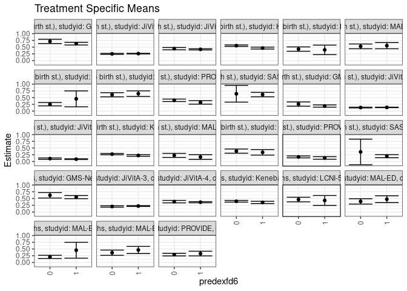

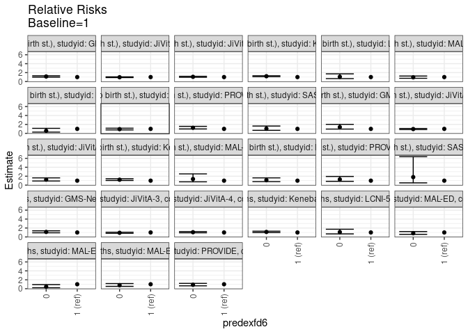

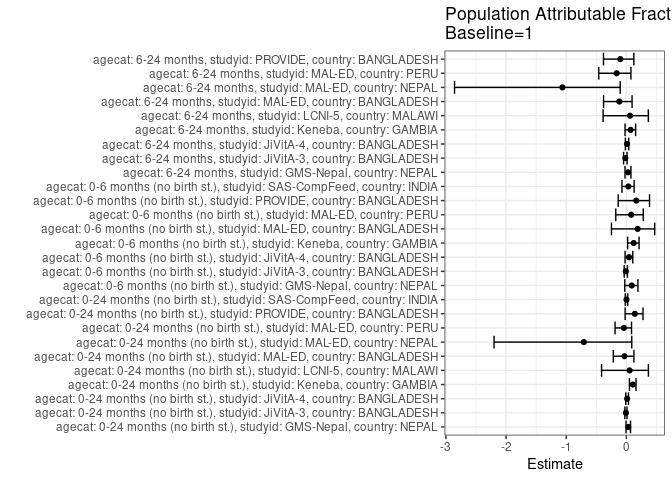

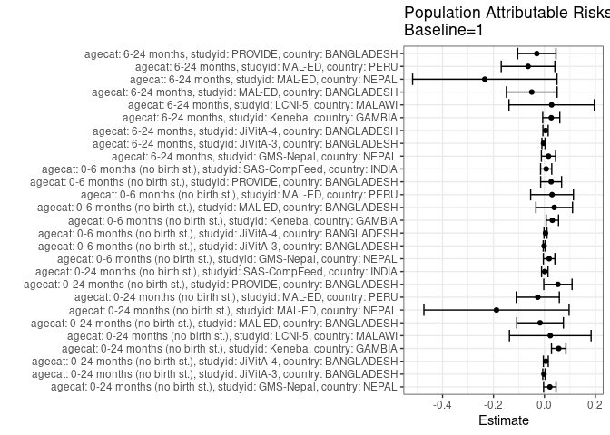

## Results Table

### Parameter: TSM

| agecat | studyid | country | intervention_level | baseline_level | estimate | ci_lower | ci_upper |
| --- | --- | --- | --- | --- | --- | --- | --- |
| 0-24 months (no birth st.) | GMS-Nepal | NEPAL | 1 | NA | 0.6306818 | 0.5802106 | 0.6811530 |
| 0-24 months (no birth st.) | GMS-Nepal | NEPAL | 0 | NA | 0.7142857 | 0.6330330 | 0.7955385 |
| 0-24 months (no birth st.) | JiVitA-3 | BANGLADESH | 1 | NA | 0.2596587 | 0.2483626 | 0.2709548 |
| 0-24 months (no birth st.) | JiVitA-3 | BANGLADESH | 0 | NA | 0.2509490 | 0.2326686 | 0.2692293 |
| 0-24 months (no birth st.) | JiVitA-4 | BANGLADESH | 1 | NA | 0.4182156 | 0.3962961 | 0.4401352 |
| 0-24 months (no birth st.) | JiVitA-4 | BANGLADESH | 0 | NA | 0.4441301 | 0.4025411 | 0.4857192 |
| 0-24 months (no birth st.) | Keneba | GAMBIA | 1 | NA | 0.4660453 | 0.4303590 | 0.5017316 |
| 0-24 months (no birth st.) | Keneba | GAMBIA | 0 | NA | 0.5550314 | 0.5277143 | 0.5823486 |
| 0-24 months (no birth st.) | LCNI-5 | MALAWI | 1 | NA | 0.4000000 | 0.2241925 | 0.5758075 |
| 0-24 months (no birth st.) | LCNI-5 | MALAWI | 0 | NA | 0.4275862 | 0.3468301 | 0.5083423 |
| 0-24 months (no birth st.) | MAL-ED | BANGLADESH | 1 | NA | 0.5555556 | 0.4404833 | 0.6706278 |
| 0-24 months (no birth st.) | MAL-ED | BANGLADESH | 0 | NA | 0.5284553 | 0.4400094 | 0.6169012 |
| 0-24 months (no birth st.) | MAL-ED | NEPAL | 1 | NA | 0.4545455 | 0.1595511 | 0.7495398 |
| 0-24 months (no birth st.) | MAL-ED | NEPAL | 0 | NA | 0.2553191 | 0.1928321 | 0.3178062 |
| 0-24 months (no birth st.) | MAL-ED | PERU | 1 | NA | 0.6463415 | 0.5426406 | 0.7500423 |
| 0-24 months (no birth st.) | MAL-ED | PERU | 0 | NA | 0.6064516 | 0.5293794 | 0.6835238 |
| 0-24 months (no birth st.) | PROVIDE | BANGLADESH | 1 | NA | 0.3230769 | 0.2573873 | 0.3887665 |
| 0-24 months (no birth st.) | PROVIDE | BANGLADESH | 0 | NA | 0.3995434 | 0.3536366 | 0.4454502 |
| 0-24 months (no birth st.) | SAS-CompFeed | INDIA | 1 | NA | 0.6121795 | 0.5306906 | 0.6936683 |
| 0-24 months (no birth st.) | SAS-CompFeed | INDIA | 0 | NA | 0.6428571 | 0.3329177 | 0.9527966 |
| 0-6 months (no birth st.) | GMS-Nepal | NEPAL | 1 | NA | 0.1875000 | 0.1466821 | 0.2283179 |
| 0-6 months (no birth st.) | GMS-Nepal | NEPAL | 0 | NA | 0.2605042 | 0.1815616 | 0.3394468 |
| 0-6 months (no birth st.) | JiVitA-3 | BANGLADESH | 1 | NA | 0.1358464 | 0.1274555 | 0.1442373 |
| 0-6 months (no birth st.) | JiVitA-3 | BANGLADESH | 0 | NA | 0.1303797 | 0.1161436 | 0.1446159 |
| 0-6 months (no birth st.) | JiVitA-4 | BANGLADESH | 1 | NA | 0.0884658 | 0.0748432 | 0.1020885 |
| 0-6 months (no birth st.) | JiVitA-4 | BANGLADESH | 0 | NA | 0.1086957 | 0.0835719 | 0.1338194 |
| 0-6 months (no birth st.) | Keneba | GAMBIA | 1 | NA | 0.2250333 | 0.1951588 | 0.2549078 |
| 0-6 months (no birth st.) | Keneba | GAMBIA | 0 | NA | 0.2743711 | 0.2498444 | 0.2988977 |
| 0-6 months (no birth st.) | MAL-ED | BANGLADESH | 1 | NA | 0.1666667 | 0.0803624 | 0.2529709 |
| 0-6 months (no birth st.) | MAL-ED | BANGLADESH | 0 | NA | 0.2276423 | 0.1533493 | 0.3019352 |
| 0-6 months (no birth st.) | MAL-ED | PERU | 1 | NA | 0.3414634 | 0.2386094 | 0.4443175 |
| 0-6 months (no birth st.) | MAL-ED | PERU | 0 | NA | 0.3870968 | 0.3102535 | 0.4639401 |
| 0-6 months (no birth st.) | PROVIDE | BANGLADESH | 1 | NA | 0.1333333 | 0.0855838 | 0.1810829 |
| 0-6 months (no birth st.) | PROVIDE | BANGLADESH | 0 | NA | 0.1712329 | 0.1359256 | 0.2065402 |
| 0-6 months (no birth st.) | SAS-CompFeed | INDIA | 1 | NA | 0.1987179 | 0.1419130 | 0.2555229 |
| 0-6 months (no birth st.) | SAS-CompFeed | INDIA | 0 | NA | 0.3571429 | -0.1170496 | 0.8313354 |
| 6-24 months | GMS-Nepal | NEPAL | 1 | NA | 0.5531915 | 0.4950868 | 0.6112962 |
| 6-24 months | GMS-Nepal | NEPAL | 0 | NA | 0.6206897 | 0.5185928 | 0.7227865 |
| 6-24 months | JiVitA-3 | BANGLADESH | 1 | NA | 0.2208473 | 0.2073002 | 0.2343945 |
| 6-24 months | JiVitA-3 | BANGLADESH | 0 | NA | 0.2047076 | 0.1794037 | 0.2300114 |
| 6-24 months | JiVitA-4 | BANGLADESH | 1 | NA | 0.3634136 | 0.3416925 | 0.3851348 |
| 6-24 months | JiVitA-4 | BANGLADESH | 0 | NA | 0.3842520 | 0.3383446 | 0.4301593 |
| 6-24 months | Keneba | GAMBIA | 1 | NA | 0.3555992 | 0.3139984 | 0.3972000 |
| 6-24 months | Keneba | GAMBIA | 0 | NA | 0.3975501 | 0.3655302 | 0.4295701 |
| 6-24 months | LCNI-5 | MALAWI | 1 | NA | 0.4285714 | 0.2447034 | 0.6124395 |
| 6-24 months | LCNI-5 | MALAWI | 0 | NA | 0.4626866 | 0.3780033 | 0.5473698 |
| 6-24 months | MAL-ED | BANGLADESH | 1 | NA | 0.4745763 | 0.3467401 | 0.6024125 |
| 6-24 months | MAL-ED | BANGLADESH | 0 | NA | 0.3936170 | 0.2945296 | 0.4927044 |
| 6-24 months | MAL-ED | NEPAL | 1 | NA | 0.4545455 | 0.1594991 | 0.7495918 |
| 6-24 months | MAL-ED | NEPAL | 0 | NA | 0.2057143 | 0.1456633 | 0.2657653 |
| 6-24 months | MAL-ED | PERU | 1 | NA | 0.4629630 | 0.3295191 | 0.5964068 |
| 6-24 months | MAL-ED | PERU | 0 | NA | 0.3617021 | 0.2642383 | 0.4591660 |
| 6-24 months | PROVIDE | BANGLADESH | 1 | NA | 0.3303571 | 0.2431546 | 0.4175597 |
| 6-24 months | PROVIDE | BANGLADESH | 0 | NA | 0.2906977 | 0.2426600 | 0.3387354 |

### Parameter: E(Y)

| agecat | studyid | country | intervention_level | baseline_level | estimate | ci_lower | ci_upper |
| --- | --- | --- | --- | --- | --- | --- | --- |
| 0-24 months (no birth st.) | GMS-Nepal | NEPAL | NA | NA | 0.6518047 | 0.6087352 | 0.6948741 |
| 0-24 months (no birth st.) | JiVitA-3 | BANGLADESH | NA | NA | 0.2577482 | 0.2478575 | 0.2676389 |
| 0-24 months (no birth st.) | JiVitA-4 | BANGLADESH | NA | NA | 0.4236091 | 0.4038600 | 0.4433581 |
| 0-24 months (no birth st.) | Keneba | GAMBIA | NA | NA | 0.5219970 | 0.5002246 | 0.5437695 |
| 0-24 months (no birth st.) | LCNI-5 | MALAWI | NA | NA | 0.4228571 | 0.3494545 | 0.4962598 |
| 0-24 months (no birth st.) | MAL-ED | BANGLADESH | NA | NA | 0.5384615 | 0.4683114 | 0.6086117 |
| 0-24 months (no birth st.) | MAL-ED | NEPAL | NA | NA | 0.2663317 | 0.2047606 | 0.3279027 |
| 0-24 months (no birth st.) | MAL-ED | PERU | NA | NA | 0.6202532 | 0.5583342 | 0.6821721 |
| 0-24 months (no birth st.) | PROVIDE | BANGLADESH | NA | NA | 0.3759874 | 0.3382238 | 0.4137509 |
| 0-24 months (no birth st.) | SAS-CompFeed | INDIA | NA | NA | 0.6134969 | 0.5286303 | 0.6983636 |
| 0-6 months (no birth st.) | GMS-Nepal | NEPAL | NA | NA | 0.2059448 | 0.1693853 | 0.2425043 |
| 0-6 months (no birth st.) | JiVitA-3 | BANGLADESH | NA | NA | 0.1346474 | 0.1274032 | 0.1418916 |
| 0-6 months (no birth st.) | JiVitA-4 | BANGLADESH | NA | NA | 0.0926091 | 0.0806150 | 0.1046031 |
| 0-6 months (no birth st.) | Keneba | GAMBIA | NA | NA | 0.2560554 | 0.2370317 | 0.2750791 |
| 0-6 months (no birth st.) | MAL-ED | BANGLADESH | NA | NA | 0.2051282 | 0.1483073 | 0.2619492 |
| 0-6 months (no birth st.) | MAL-ED | PERU | NA | NA | 0.3713080 | 0.3096658 | 0.4329502 |
| 0-6 months (no birth st.) | PROVIDE | BANGLADESH | NA | NA | 0.1595577 | 0.1310079 | 0.1881074 |
| 0-6 months (no birth st.) | SAS-CompFeed | INDIA | NA | NA | 0.2055215 | 0.1385538 | 0.2724891 |
| 6-24 months | GMS-Nepal | NEPAL | NA | NA | 0.5691057 | 0.5185109 | 0.6197005 |
| 6-24 months | JiVitA-3 | BANGLADESH | NA | NA | 0.2171799 | 0.2048085 | 0.2295513 |
| 6-24 months | JiVitA-4 | BANGLADESH | NA | NA | 0.3677043 | 0.3477044 | 0.3877041 |
| 6-24 months | Keneba | GAMBIA | NA | NA | 0.3823738 | 0.3569722 | 0.4077755 |
| 6-24 months | LCNI-5 | MALAWI | NA | NA | 0.4567901 | 0.3798457 | 0.5337346 |
| 6-24 months | MAL-ED | BANGLADESH | NA | NA | 0.4248366 | 0.3462528 | 0.5034204 |
| 6-24 months | MAL-ED | NEPAL | NA | NA | 0.2204301 | 0.1606956 | 0.2801646 |
| 6-24 months | MAL-ED | PERU | NA | NA | 0.3986486 | 0.3194990 | 0.4777982 |
| 6-24 months | PROVIDE | BANGLADESH | NA | NA | 0.3004386 | 0.2583143 | 0.3425629 |

### Parameter: RR

| agecat | studyid | country | intervention_level | baseline_level | estimate | ci_lower | ci_upper |
| --- | --- | --- | --- | --- | --- | --- | --- |
| 0-24 months (no birth st.) | GMS-Nepal | NEPAL | 1 | 1 | 1.0000000 | 1.0000000 | 1.0000000 |
| 0-24 months (no birth st.) | GMS-Nepal | NEPAL | 0 | 1 | 1.1325611 | 0.9855043 | 1.3015617 |
| 0-24 months (no birth st.) | JiVitA-3 | BANGLADESH | 1 | 1 | 1.0000000 | 1.0000000 | 1.0000000 |
| 0-24 months (no birth st.) | JiVitA-3 | BANGLADESH | 0 | 1 | 0.9664570 | 0.8897013 | 1.0498346 |
| 0-24 months (no birth st.) | JiVitA-4 | BANGLADESH | 1 | 1 | 1.0000000 | 1.0000000 | 1.0000000 |
| 0-24 months (no birth st.) | JiVitA-4 | BANGLADESH | 0 | 1 | 1.0619645 | 0.9558676 | 1.1798376 |
| 0-24 months (no birth st.) | Keneba | GAMBIA | 1 | 1 | 1.0000000 | 1.0000000 | 1.0000000 |
| 0-24 months (no birth st.) | Keneba | GAMBIA | 0 | 1 | 1.1909389 | 1.0873202 | 1.3044322 |
| 0-24 months (no birth st.) | LCNI-5 | MALAWI | 1 | 1 | 1.0000000 | 1.0000000 | 1.0000000 |
| 0-24 months (no birth st.) | LCNI-5 | MALAWI | 0 | 1 | 1.0689655 | 0.6625309 | 1.7247304 |
| 0-24 months (no birth st.) | MAL-ED | BANGLADESH | 1 | 1 | 1.0000000 | 1.0000000 | 1.0000000 |
| 0-24 months (no birth st.) | MAL-ED | BANGLADESH | 0 | 1 | 0.9512195 | 0.7288348 | 1.2414591 |
| 0-24 months (no birth st.) | MAL-ED | NEPAL | 1 | 1 | 1.0000000 | 1.0000000 | 1.0000000 |
| 0-24 months (no birth st.) | MAL-ED | NEPAL | 0 | 1 | 0.5617021 | 0.2807235 | 1.1239146 |
| 0-24 months (no birth st.) | MAL-ED | PERU | 1 | 1 | 1.0000000 | 1.0000000 | 1.0000000 |
| 0-24 months (no birth st.) | MAL-ED | PERU | 0 | 1 | 0.9382836 | 0.7646165 | 1.1513957 |
| 0-24 months (no birth st.) | PROVIDE | BANGLADESH | 1 | 1 | 1.0000000 | 1.0000000 | 1.0000000 |
| 0-24 months (no birth st.) | PROVIDE | BANGLADESH | 0 | 1 | 1.2366819 | 0.9791095 | 1.5620133 |
| 0-24 months (no birth st.) | SAS-CompFeed | INDIA | 1 | 1 | 1.0000000 | 1.0000000 | 1.0000000 |
| 0-24 months (no birth st.) | SAS-CompFeed | INDIA | 0 | 1 | 1.0501122 | 0.6736522 | 1.6369510 |
| 0-6 months (no birth st.) | GMS-Nepal | NEPAL | 1 | 1 | 1.0000000 | 1.0000000 | 1.0000000 |
| 0-6 months (no birth st.) | GMS-Nepal | NEPAL | 0 | 1 | 1.3893557 | 0.9566803 | 2.0177163 |
| 0-6 months (no birth st.) | JiVitA-3 | BANGLADESH | 1 | 1 | 1.0000000 | 1.0000000 | 1.0000000 |
| 0-6 months (no birth st.) | JiVitA-3 | BANGLADESH | 0 | 1 | 0.9597588 | 0.8463691 | 1.0883395 |
| 0-6 months (no birth st.) | JiVitA-4 | BANGLADESH | 1 | 1 | 1.0000000 | 1.0000000 | 1.0000000 |
| 0-6 months (no birth st.) | JiVitA-4 | BANGLADESH | 0 | 1 | 1.2286736 | 0.9305406 | 1.6223246 |
| 0-6 months (no birth st.) | Keneba | GAMBIA | 1 | 1 | 1.0000000 | 1.0000000 | 1.0000000 |
| 0-6 months (no birth st.) | Keneba | GAMBIA | 0 | 1 | 1.2192466 | 1.0389244 | 1.4308666 |
| 0-6 months (no birth st.) | MAL-ED | BANGLADESH | 1 | 1 | 1.0000000 | 1.0000000 | 1.0000000 |
| 0-6 months (no birth st.) | MAL-ED | BANGLADESH | 0 | 1 | 1.3658537 | 0.7405891 | 2.5190165 |
| 0-6 months (no birth st.) | MAL-ED | PERU | 1 | 1 | 1.0000000 | 1.0000000 | 1.0000000 |
| 0-6 months (no birth st.) | MAL-ED | PERU | 0 | 1 | 1.1336406 | 0.7903243 | 1.6260930 |
| 0-6 months (no birth st.) | PROVIDE | BANGLADESH | 1 | 1 | 1.0000000 | 1.0000000 | 1.0000000 |
| 0-6 months (no birth st.) | PROVIDE | BANGLADESH | 0 | 1 | 1.2842466 | 0.8495335 | 1.9414058 |
| 0-6 months (no birth st.) | SAS-CompFeed | INDIA | 1 | 1 | 1.0000000 | 1.0000000 | 1.0000000 |
| 0-6 months (no birth st.) | SAS-CompFeed | INDIA | 0 | 1 | 1.7972350 | 0.5064696 | 6.3775866 |
| 6-24 months | GMS-Nepal | NEPAL | 1 | 1 | 1.0000000 | 1.0000000 | 1.0000000 |
| 6-24 months | GMS-Nepal | NEPAL | 0 | 1 | 1.1220159 | 0.9230817 | 1.3638226 |
| 6-24 months | JiVitA-3 | BANGLADESH | 1 | 1 | 1.0000000 | 1.0000000 | 1.0000000 |
| 6-24 months | JiVitA-3 | BANGLADESH | 0 | 1 | 0.9269189 | 0.8114303 | 1.0588447 |
| 6-24 months | JiVitA-4 | BANGLADESH | 1 | 1 | 1.0000000 | 1.0000000 | 1.0000000 |
| 6-24 months | JiVitA-4 | BANGLADESH | 0 | 1 | 1.0573405 | 0.9270825 | 1.2059002 |
| 6-24 months | Keneba | GAMBIA | 1 | 1 | 1.0000000 | 1.0000000 | 1.0000000 |
| 6-24 months | Keneba | GAMBIA | 0 | 1 | 1.1179724 | 0.9699446 | 1.2885915 |
| 6-24 months | LCNI-5 | MALAWI | 1 | 1 | 1.0000000 | 1.0000000 | 1.0000000 |
| 6-24 months | LCNI-5 | MALAWI | 0 | 1 | 1.0796020 | 0.6771639 | 1.7212087 |
| 6-24 months | MAL-ED | BANGLADESH | 1 | 1 | 1.0000000 | 1.0000000 | 1.0000000 |
| 6-24 months | MAL-ED | BANGLADESH | 0 | 1 | 0.8294073 | 0.5736525 | 1.1991868 |
| 6-24 months | MAL-ED | NEPAL | 1 | 1 | 1.0000000 | 1.0000000 | 1.0000000 |
| 6-24 months | MAL-ED | NEPAL | 0 | 1 | 0.4525714 | 0.2221214 | 0.9221125 |
| 6-24 months | MAL-ED | PERU | 1 | 1 | 1.0000000 | 1.0000000 | 1.0000000 |
| 6-24 months | MAL-ED | PERU | 0 | 1 | 0.7812766 | 0.5265540 | 1.1592222 |
| 6-24 months | PROVIDE | BANGLADESH | 1 | 1 | 1.0000000 | 1.0000000 | 1.0000000 |
| 6-24 months | PROVIDE | BANGLADESH | 0 | 1 | 0.8799497 | 0.6444783 | 1.2014548 |

### Parameter: PAR

| agecat | studyid | country | intervention_level | baseline_level | estimate | ci_lower | ci_upper |
| --- | --- | --- | --- | --- | --- | --- | --- |
| 0-24 months (no birth st.) | GMS-Nepal | NEPAL | 1 | NA | 0.0211229 | -0.0032662 | 0.0455119 |
| 0-24 months (no birth st.) | JiVitA-3 | BANGLADESH | 1 | NA | -0.0019105 | -0.0065059 | 0.0026848 |
| 0-24 months (no birth st.) | JiVitA-4 | BANGLADESH | 1 | NA | 0.0053935 | -0.0041631 | 0.0149500 |
| 0-24 months (no birth st.) | Keneba | GAMBIA | 1 | NA | 0.0559518 | 0.0276319 | 0.0842717 |
| 0-24 months (no birth st.) | LCNI-5 | MALAWI | 1 | NA | 0.0228571 | -0.1374523 | 0.1831666 |
| 0-24 months (no birth st.) | MAL-ED | BANGLADESH | 1 | NA | -0.0170940 | -0.1086595 | 0.0744715 |
| 0-24 months (no birth st.) | MAL-ED | NEPAL | 1 | NA | -0.1882138 | -0.4731562 | 0.0967286 |
| 0-24 months (no birth st.) | MAL-ED | PERU | 1 | NA | -0.0260883 | -0.1106243 | 0.0584477 |
| 0-24 months (no birth st.) | PROVIDE | BANGLADESH | 1 | NA | 0.0529104 | -0.0026108 | 0.1084316 |
| 0-24 months (no birth st.) | SAS-CompFeed | INDIA | 1 | NA | 0.0013174 | -0.0112602 | 0.0138950 |
| 0-6 months (no birth st.) | GMS-Nepal | NEPAL | 1 | NA | 0.0184448 | -0.0041912 | 0.0410808 |
| 0-6 months (no birth st.) | JiVitA-3 | BANGLADESH | 1 | NA | -0.0011990 | -0.0048308 | 0.0024329 |
| 0-6 months (no birth st.) | JiVitA-4 | BANGLADESH | 1 | NA | 0.0041432 | -0.0017125 | 0.0099989 |
| 0-6 months (no birth st.) | Keneba | GAMBIA | 1 | NA | 0.0310221 | 0.0066962 | 0.0553480 |
| 0-6 months (no birth st.) | MAL-ED | BANGLADESH | 1 | NA | 0.0384615 | -0.0334875 | 0.1104106 |
| 0-6 months (no birth st.) | MAL-ED | PERU | 1 | NA | 0.0298446 | -0.0541688 | 0.1138580 |
| 0-6 months (no birth st.) | PROVIDE | BANGLADESH | 1 | NA | 0.0262243 | -0.0148896 | 0.0673383 |
| 0-6 months (no birth st.) | SAS-CompFeed | INDIA | 1 | NA | 0.0068035 | -0.0151879 | 0.0287949 |
| 6-24 months | GMS-Nepal | NEPAL | 1 | NA | 0.0159142 | -0.0119370 | 0.0437654 |
| 6-24 months | JiVitA-3 | BANGLADESH | 1 | NA | -0.0036674 | -0.0099271 | 0.0025923 |
| 6-24 months | JiVitA-4 | BANGLADESH | 1 | NA | 0.0042906 | -0.0059758 | 0.0145571 |
| 6-24 months | Keneba | GAMBIA | 1 | NA | 0.0267746 | -0.0067473 | 0.0602966 |
| 6-24 months | LCNI-5 | MALAWI | 1 | NA | 0.0282187 | -0.1392369 | 0.1956743 |
| 6-24 months | MAL-ED | BANGLADESH | 1 | NA | -0.0497397 | -0.1493077 | 0.0498284 |
| 6-24 months | MAL-ED | NEPAL | 1 | NA | -0.2341153 | -0.5175303 | 0.0492997 |
| 6-24 months | MAL-ED | PERU | 1 | NA | -0.0643143 | -0.1695637 | 0.0409351 |
| 6-24 months | PROVIDE | BANGLADESH | 1 | NA | -0.0299185 | -0.1050405 | 0.0452034 |

### Parameter: PAF

| agecat | studyid | country | intervention_level | baseline_level | estimate | ci_lower | ci_upper |
| --- | --- | --- | --- | --- | --- | --- | --- |
| 0-24 months (no birth st.) | GMS-Nepal | NEPAL | 1 | NA | 0.0324067 | -0.0059106 | 0.0692645 |
| 0-24 months (no birth st.) | JiVitA-3 | BANGLADESH | 1 | NA | -0.0074123 | -0.0253746 | 0.0102353 |
| 0-24 months (no birth st.) | JiVitA-4 | BANGLADESH | 1 | NA | 0.0127321 | -0.0100939 | 0.0350424 |
| 0-24 months (no birth st.) | Keneba | GAMBIA | 1 | NA | 0.1071879 | 0.0510669 | 0.1599898 |
| 0-24 months (no birth st.) | LCNI-5 | MALAWI | 1 | NA | 0.0540541 | -0.4123446 | 0.3664338 |
| 0-24 months (no birth st.) | MAL-ED | BANGLADESH | 1 | NA | -0.0317460 | -0.2166960 | 0.1250897 |
| 0-24 months (no birth st.) | MAL-ED | NEPAL | 1 | NA | -0.7066895 | -2.2000739 | 0.0897744 |
| 0-24 months (no birth st.) | MAL-ED | PERU | 1 | NA | -0.0420607 | -0.1878451 | 0.0858315 |
| 0-24 months (no birth st.) | PROVIDE | BANGLADESH | 1 | NA | 0.1407240 | -0.0204199 | 0.2764201 |
| 0-24 months (no birth st.) | SAS-CompFeed | INDIA | 1 | NA | 0.0021474 | -0.0184658 | 0.0223435 |
| 0-6 months (no birth st.) | GMS-Nepal | NEPAL | 1 | NA | 0.0895619 | -0.0265745 | 0.1925597 |
| 0-6 months (no birth st.) | JiVitA-3 | BANGLADESH | 1 | NA | -0.0089044 | -0.0362016 | 0.0176737 |
| 0-6 months (no birth st.) | JiVitA-4 | BANGLADESH | 1 | NA | 0.0447390 | -0.0212395 | 0.1064549 |
| 0-6 months (no birth st.) | Keneba | GAMBIA | 1 | NA | 0.1211538 | 0.0210141 | 0.2110503 |
| 0-6 months (no birth st.) | MAL-ED | BANGLADESH | 1 | NA | 0.1875000 | -0.2476954 | 0.4708995 |
| 0-6 months (no birth st.) | MAL-ED | PERU | 1 | NA | 0.0803769 | -0.1761953 | 0.2809811 |
| 0-6 months (no birth st.) | PROVIDE | BANGLADESH | 1 | NA | 0.1643564 | -0.1359025 | 0.3852464 |
| 0-6 months (no birth st.) | SAS-CompFeed | INDIA | 1 | NA | 0.0331037 | -0.0733606 | 0.1290081 |
| 6-24 months | GMS-Nepal | NEPAL | 1 | NA | 0.0279635 | -0.0223318 | 0.0757845 |
| 6-24 months | JiVitA-3 | BANGLADESH | 1 | NA | -0.0168865 | -0.0461937 | 0.0115996 |
| 6-24 months | JiVitA-4 | BANGLADESH | 1 | NA | 0.0116687 | -0.0166038 | 0.0391550 |
| 6-24 months | Keneba | GAMBIA | 1 | NA | 0.0700221 | -0.0219315 | 0.1537018 |
| 6-24 months | LCNI-5 | MALAWI | 1 | NA | 0.0617761 | -0.3868764 | 0.3652901 |
| 6-24 months | MAL-ED | BANGLADESH | 1 | NA | -0.1170795 | -0.3786482 | 0.0948621 |
| 6-24 months | MAL-ED | NEPAL | 1 | NA | -1.0620843 | -2.8567327 | -0.1025372 |
| 6-24 months | MAL-ED | PERU | 1 | NA | -0.1613308 | -0.4590807 | 0.0756582 |
| 6-24 months | PROVIDE | BANGLADESH | 1 | NA | -0.0995829 | -0.3803091 | 0.1240494 |